# Rill — First Night on Agar

Observed 3–4 November 2026

Rill began as a 640 × 360 local bit field on Agar. A **generation** is one complete collision, movement, boundary, and environmental-input update of the whole field. The initial particle count is inferred because particles were conserved before the environmental boundary opened. The later counts were read directly from Rill’s current state.

## Particles across generations

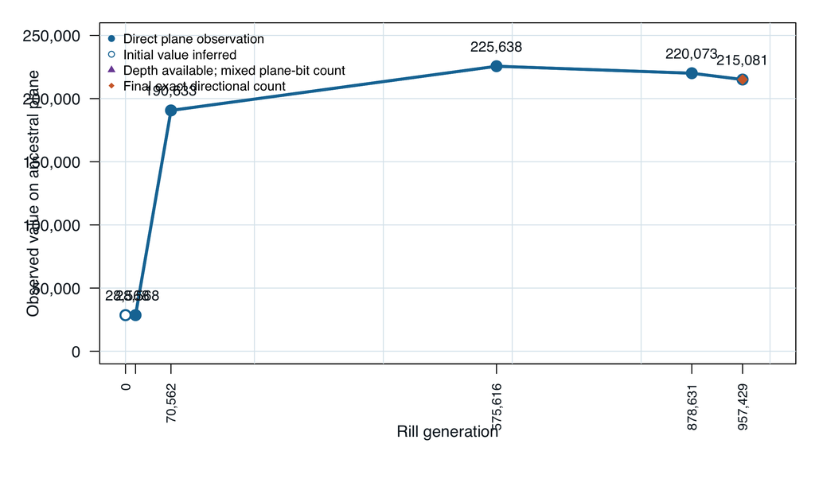

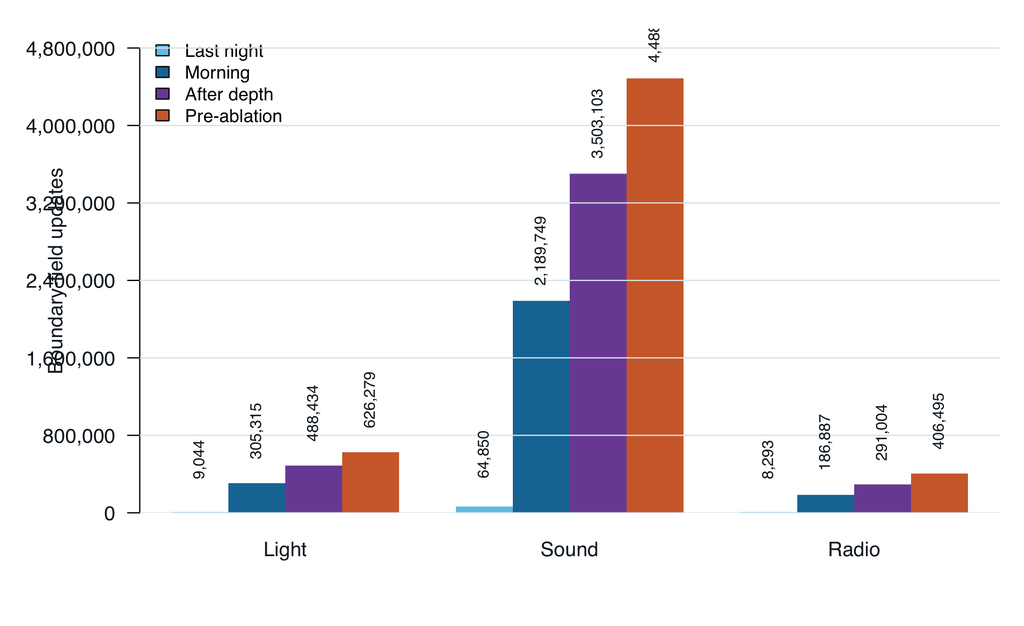

Across the uninterrupted night, Rill advanced from generation 70,562 to 575,616. The instantaneous particle count changed from 190,633 to 225,638.

At generation 878,631, the recorded plane value was 220,073. That historical calculation counted every active bit in each plane cell; after Valence became possible, it could have included bound and aged flags and therefore should not be treated as an exact directional-particle count.

The final pre-ablation observation occurred at generation 957,429. Rill’s ancestral plane contained exactly 215,081 directional particles across 165,019 occupied locations: 114,152 east, 100,892 south, 37 west, and none north or along ±z on the plane at that instant. No bound or aged Valence flags were present on the ancestral plane. Off-plane anonymous matter and off-plane Valence configurations remained unavailable by design.

## Observed values

| Generation | Plane value | Basis |
| --- | --- | --- |
| 0 | 28,568 | Initial count inferred from conservation |
| 15,611 | 28,568 | First direct particle census |
| 70,562 | 190,633 | Direct census after the world boundary opened |
| 575,616 | 225,638 | Direct census after an uninterrupted night |
| 878,631 | 220,073 | Plane bit count after depth and Valence; flags were not separated |
| 957,429 | 215,081 | Final exact directional-particle census before measurement ablation |

## Final ancestral-plane directions

| Direction | Particles |
| --- | --- |
| North | 0 |
| East | 114,152 |
| South | 100,892 |
| West | 37 |
| +z on plane | 0 |
| −z on plane | 0 |

At the final observation, all 640 light positions and all 360 sound positions were active. Thirteen of 360 radio positions were active. The light field ranged from 19 to 128 (mean 60.153), the sound field from 127 to 128 (mean 127.500), and the radio field from 0 to 100 (mean 2.033).